# Shifts in species and phylogenetic diversity between sapling and tree communities indicate negative density dependence in a lowland rain forest - Gonzalez - 2010 - Journal of Ecology - Wiley Online Li

[Journal of Ecology](https://besjournals.onlinelibrary.wiley.com/journal/13652745)

[Volume 98, Issue 1](https://besjournals.onlinelibrary.wiley.com/toc/13652745/2010/98/1) p. 137-146

[figure not shown]

Free Access

# Shifts in species and phylogenetic diversity between sapling and tree communities indicate negative density dependence in a lowland rain forest

[Mailyn A. Gonzalez](https://besjournals.onlinelibrary.wiley.com/authored-by/ContribAuthorRaw/Gonzalez/Mailyn+A.),

*Correspondence author. E-mail:

[Aurélien Roger](https://besjournals.onlinelibrary.wiley.com/authored-by/ContribAuthorRaw/Roger/Aur%C3%A9lien),

[Elodie A. Courtois](https://besjournals.onlinelibrary.wiley.com/authored-by/ContribAuthorRaw/Courtois/Elodie+A.),

[Franck Jabot](https://besjournals.onlinelibrary.wiley.com/authored-by/ContribAuthorRaw/Jabot/Franck),

[Natalia Norden](https://besjournals.onlinelibrary.wiley.com/authored-by/ContribAuthorRaw/Norden/Natalia),

[C. E. Timothy Paine](https://besjournals.onlinelibrary.wiley.com/authored-by/ContribAuthorRaw/Paine/C.+E.+Timothy),

[Christopher Baraloto](https://besjournals.onlinelibrary.wiley.com/authored-by/ContribAuthorRaw/Baraloto/Christopher),

[Christophe Thébaud](https://besjournals.onlinelibrary.wiley.com/authored-by/ContribAuthorRaw/Th%C3%A9baud/Christophe),

[Jérôme Chave](https://besjournals.onlinelibrary.wiley.com/authored-by/ContribAuthorRaw/Chave/J%C3%A9r%C3%B4me),

First published: 11 December 2009

https://doi.org/10.1111/j.1365-2745.2009.01607.x

Citations: 56

## Summary

**1.** As trees in a given cohort progress through ontogeny, many individuals die. This risk of mortality is unevenly distributed across species because of many processes such as habitat filtering, interspecific competition and negative density dependence. Here, we predict and test the patterns that such ecological processes should inscribe on both species and phylogenetic diversity as plants recruit from saplings to the canopy.

**2.** We compared species and phylogenetic diversity of sapling and tree communities at two sites in French Guiana. We surveyed 2084 adult trees in four 1-ha tree plots and 943 saplings in sixteen 16-m<sup>2</sup> subplots nested within the tree plots. Species diversity was measured using Fisher’s alpha (species richness) and Simpson’s index (species evenness). Phylogenetic diversity was measured using Faith’s phylogenetic diversity (phylogenetic richness) and Rao’s quadratic entropy index (phylogenetic evenness). The phylogenetic diversity indices were inferred using four phylogenetic hypotheses: two based on *rbcLa* plastid DNA sequences obtained from the inventoried individuals with different branch lengths, a global phylogeny available from the Angiosperm Phylogeny Group, and a combination of both.

**3.** Taxonomic identification of the saplings was performed by combining morphological and DNA barcoding techniques using three plant DNA barcodes (*psbA-trnH*, *rpoC1* and *rbcLa*). DNA barcoding enabled us to increase species assignment and to assign unidentified saplings to molecular operational taxonomic units.

**4.** Species richness was similar between saplings and trees, but in about half of our comparisons, species evenness was higher in trees than in saplings. This suggests that negative density dependence plays an important role during the sapling-to-tree transition.

**6.** *Synthesis.* By contrasting species richness and evenness across size classes, we suggest that negative density dependence drives shifts in composition during the sapling-to-tree transition. In addition, we found little evidence for a change in phylogenetic diversity across age classes, suggesting that the observed patterns are not phylogenetically constrained.

## Introduction

Identifying the mechanisms of plant community assembly and species coexistence is a major research topic in ecology (Zobel 1992; Tilman & Pacala 1993; Hubbell 2001; Webb *et al.* 2002; Wright 2002; Cavender-Bares *et al.* 2004). The ‘regeneration niche’ (*sensu*Grubb 1977, 1986) has received much attention because filters to species establishment are known to occur early on in the life of plants. Seed germination and establishment are limited by several factors such as resource availability (also known as ‘habitat filtering’, Baraloto, Bonal & Goldberg 2006; Norden *et al.* 2009), interspecific competition (Tilman 1982; Coomes & Grubb 2000), or negative density dependence (Janzen 1970; Connell 1971; Harms *et al.* 2000; HilleRisLambers, Clark & Beckage 2002; Bell, Freckleton & Lewis 2006; Paine & Beck 2007). It has been proposed that beyond the regeneration phase, both negative density dependence (Wills *et al.* 1997, 2006; Peters 2003; Queenborough *et al.* 2007; Comita & Hubbell 2009) and habitat filtering (Webb & Peart 2000; Paoli, Curran & Zack 2006; Comita, Condit & Hubbell 2007) are important mechanisms structuring tropical plant communities. In this study, we seek to elucidate ecological mechanisms shaping diversity after the regeneration stage by comparing species and phylogenetic diversity between sapling and tree communities (we define here saplings as established juvenile plants with well-developed leaves and roots; see Materials and methods, for an operational definition).

In forests, species diversity between the sapling and the tree communities may increase, decrease or remain unchanged, depending on the relative importance of the ecological mechanism involved (Table 1). If species recruitment success fluctuates through time, a frequency-dependent mechanism referred to as the storage effect (Warner & Chesson 1985), both species richness and evenness should increase from the sapling to the tree stages, since trees may comprise a larger number of cohorts. However, the storage effect may be barely detectable in species richness if many saplings are long-lived. A comparable pattern of increasing species evenness and unchanged species richness during the sapling-to-tree transition is also expected under negative density-dependent processes that favour rare species over abundant ones. Conversely, both environmental filtering and interspecific competition result in decreased species diversity as cohorts age, since species intolerant of local environmental conditions are less likely to persist. Finally, species diversity may not change during the sapling-to-tree transition if the filters have acted before the sapling stage has been reached, or if several counteracting mechanisms balance each other out. In sum, the storage effect and negative density dependence would increase species diversity through time, whereas environmental filtering and interspecific competition would reduce species diversity. Thus, solely assessing changes of species diversity across size classes is not enough to distinguish among the different mechanisms, which can shape community assembly.

Table 1. Predicted effects of different ecological processes on community structure of trees relative to saplings, measured using the tree–sapling differences for indices that describe species and phylogenetic diversity measuring richness and evenness. ‘+’ represents an increase in diversity from saplings to trees, ‘−’ represents a decrease in diversity and ‘0’ represents no significant changes of diversity

| Ecological mechanism | Tree–sapling species diversity Fisher’s alpha | Tree–sapling species diversity Simpson index | Tree–sapling phylogenetic diversity* Faith’s PD | Tree–sapling phylogenetic diversity* Rao’s quadratic entropy (Dp) |
| --- | --- | --- | --- | --- |
| Conspecific density dependence | 0 | + | 0 | 0 |
| Phylogenetic density dependence | 0 | + | 0 | + |
| Habitat filtering | − | − | − | − |
| Competition | − | − | + | + |
| Storage effect | 0/+ | + | 0/+ | 0/+ |
| Neutrality | 0 | 0 | 0 | 0 |

- *Assuming phylogenetic niche conservatism.

Phylogenetic information can help to distinguish among the mechanisms that can shape community structure, since these mechanisms may have a different imprint on phylogenetic diversity than on species diversity (Table 1). The effect of ecological mechanisms on phylogenetic diversity depends on the phylogenetic dispersion of species niches. It is generally found that closely related species occupy more similar niches than do less-related species, a pattern referred to as phylogenetic niche conservatism (Blomberg, Garland & Ives 2003; Losos 2008). Support for the assumption of phylogenetic niche conservatism in plants has been suggested by Ricklefs & Latham (1992) for grass species, and by Crisp *et al.* (2009) for a large number of plants of the southern hemisphere (see also Prinzing *et al.* 2001; Swenson & Enquist 2009). In this study, we assume that species niches are phylogenetically conserved in the tree species of French Guiana. Based on this assumption, we reason that habitat filtering would decrease phylogenetic diversity across life stages as only species tolerant of local environmental conditions would persist in the community, and those species are likely to be closely related to one another. Conversely, interspecific competition would increase phylogenetic diversity as distantly related species would differ in their niches and should be able to coexist (Table 1, Webb *et al.* 2002). As with measures of species diversity, phylogenetic diversity may be partitioned into richness and evenness and these measures may also reveal a different picture. For example, negative conspecific density dependence should not alter Faith’s PD, a measure of phylogenetic richness, nor Rao’s quadratic entropy (Dp), a measure of phylogenetic evenness, since this process should be independent of phylogenetic relationships, with all lineages persisting in the community. However, if negative density dependence acts between close relatives, a mechanism referred to as phylogenetic density dependence, then its action should lead to an increase in Dp between life stages whereas Faith’s PD may not change (Webb, Gilbert & Donoghue 2006). Similarly to negative density dependence, the storage effect may or may not increase phylogenetic diversity between life stages depending on the phylogenetic signal of the recruitment events.

We here apply the above framework to original data collected at two sites in the lowland rain forest of French Guiana to analyse ecological mechanisms acting after the seedling recruitment phase. We use data from tree plots and nested sapling plots to assess the changes in species and phylogenetic diversity and between sapling and tree communities. This design enables us to compare sapling and tree communities in similar environments. However, our design could be compromised by the small spatial scale at which the data were collected, especially if the sapling communities are only a subset of the surrounding tree communities, which is possible if there is extreme dispersal limitation. Such a process appears to be common in rain forest trees (Wright *et al.* 2005; but see Kobe & Vriesendorp 2009) and if it operates at the scale of our comparison, then a lower diversity of sapling communities could simply be a result of dispersal limitation. We thus first tested that the sapling community is not a subset of the immediately surrounding adult community. Then, we weighed the relative importance of several ecological mechanisms shaping community structure across these size classes, using both richness and evenness calculations of species and phylogenetic diversity.

## Materials and methods

### Sampling site and collected data

This study was conducted at two sites in French Guiana, the Nouragues Research Station (4°05′ N, 52°40′ W; Bongers *et al.* 2001) and the Paracou Research Station (Fig. 1, 5°15′ N, 52°55′ W, Gourlet-Fleury, Guehl & Larouissinie 2004). Nouragues is covered with an undisturbed tropical rain forest, whereas Paracou, located about 130 km north of Nouragues, has undergone moderate hunting pressure; some plots near our study site at Paracou were artificially disturbed in 1986 (Gourlet-Fleury, Guehl & Larouissinie 2004). The local floras of Nouragues and Paracou include more than 500 tree species (Bongers *et al.* 2001; Molino & Sabatier 2001). The sites receive similar quantities of rainfall (2990 mm year<sup>−1</sup> at Nouragues, and 3041 mm year<sup>−1</sup> at Paracou).

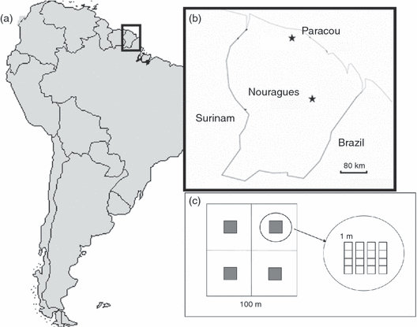

**Figure 1**

Geographical location of sampled sites in French Guiana (a,b). A total of 4 ha of forest were sampled, two 1-ha plots at the Nouragues Station (NL11, NH20) and two 1-ha plots at the Paracou Station (P006, P018). Each hectare was divided into four 50 × 50 m tree plots (c). Nested in the tree plots, a sapling plot (4 × 4 m) was placed with tree walkways of 0.5 m (inset). All juvenile trees >30 cm in height and <1 cm d.b.h. were sampled in the sapling plots. In the tree plot, all freely standing woody plants >10 cm in d.b.h. were sampled.

At each site, we sampled two 100 × 100 m (1 ha) plots separated by *c.* 1 km to capture different soil conditions. At Nouragues, one plot was on a metamorphic volcanic substrate (NL11), and the other on sandy granite-derived soil (NH20). At Paracou, one plot was on lateritic soils (P006) and the other on brown sands (P0186). For each tree at least 10 cm in diameter at breast height (d.b.h.), we collected a herbarium voucher with the assistance of professional climbers. Then, we sampled saplings with a design adapted from that of Webb & Peart (1999). Each one-hectare plot was subdivided into four square subplots of 50 × 50 m. At the centre of each subplot, we established a 4 × 4 m plot (Fig. 1) within which we tagged, measured and identified all free-standing woody saplings >30 cm in height and <1 cm d.b.h. We only report here on saplings of tree species: we excluded lianas, shrubs and palms from the dataset to avoid inflating sapling diversity. For both trees and saplings, 1–10 cm<sup>2</sup> of leaf tissue was collected and stored in silica gel for subsequent molecular analysis.

### Species identification

Trees were identified either onsite or at the Cayenne Herbarium (CAY). Sapling identification was more difficult because saplings often lack diagnostic characters (Webb & Peart 2000; Kobe & Vriesendorp 2009). We identified saplings using juvenile reference criteria established in previous studies (Baraloto & Forget 2007; Norden *et al.* 2007), and assigned morphospecies to those individuals for which species-level determination was impossible. We further used DNA barcoding to improve the information about species identification (CBOL Plant Working Group 2009; Chase & Fay 2009; Gonzalez *et al.* 2009). Total DNA was extracted from leaf tissue, and the following plastid DNA markers were sequenced: *rpoC1* (592 bp), *rbcLa* (697 bp, Newmaster, Fazekas & Ragupathy 2006; Kress & Erickson 2007; Chase *et al.* 2007; Lahaye *et al.* 2008; Gonzalez *et al.* 2009) and the intergenic spacer *psbA-trnH* (270–792 bp, Kress & Erickson 2007; Gonzalez *et al.* 2009). We sequenced *psbA-trnH* for at least one individual per sapling taxon, in addition to all individuals that remained unidentified using morphological characters. The resulting *psbA-trnH* sequence was used to assign individuals to a molecular operational taxonomic unit (henceforth MOTU), using an aggregative linkage algorithm based on the megablast software (Zhang *et al.* 2000). Then for each MOTU, we used a sequence of the less variable marker (*rbcLa* or *rpoC1*) to assign the cluster to the genus or the family level. As part of another project, we have developed a reference DNA barcode database for trees of French Guiana (Gonzalez *et al.*, unpublished data). We used that database to assign sapling MOTUs to their corresponding tree taxa. Further details of molecular methods are available in the Supporting Information (Appendix S1).

### Statistical methods

**Change of species diversity across life stages** Changes in species diversity during the sapling-to-tree transition were assessed using both Fisher’s alpha and the Simpson index (Magurran 2004). The Simpson index differs from Fisher’s alpha in that it incorporates abundance and thus weighs abundant species more than rare species. Therefore, Fisher’s alpha may be seen as a measure of species richness and the Simpson index as a measure of evenness. Both indices were calculated in each tree and sapling plot, using the package vegan in the r statistical software (Oksanen *et al.* 2008; R Development Core Team 2008). To test whether diversity changed significantly across life stages, we computed the observed tree diversity minus sapling diversity for each tree–sapling plot (*N* = 16) and compared these values to those obtained from 1000 randomized communities. Random communities were drawn from pooled individuals for each tree–sapling plot without replacement, while maintaining the observed sapling and tree abundances. Significance tests in the comparison of observed values and the randomized distribution were based on two-tailed tests.

Trees and saplings that remained poorly identified represent an uncertain number of species. In addition, we could not assign some saplings to a life-form (tree, shrub or liana) with high confidence. To account for these uncertainties, diversity analyses were conducted in two extremely conservative ways. We either included both poorly identified individuals (assuming that they each represented different species) and saplings with indeterminate life-form (assuming they were canopy tree species) or excluded them altogether. In the first case, we inflated the sapling diversity, whereas in the second case we provided a lower bound on sapling diversity. We report only the analyses based on including all individuals, as this highly conservative choice avoids underestimating sapling diversity. Analyses excluding problematic individuals yielded similar diversity patterns as those including them, and they are reported in the Supporting Information (Figs S1 and S2).

Most previous plant ecological studies have relied on megatree hypotheses, frequently using the database available in the phylomatic software (Webb & Donoghue 2005). However, it is unclear how differences among trees in terms of resolution and branch lengths would change ecological inferences. We therefore compared a phylomatic tree to our *rbcL* tree and to a grafting of the two methods. In all cases, branch lengths were obtained and nodes were dated by applying the bladj algorithm of phylocom software v 4.0.1 (Webb, Ackerly & Kembel 2008), with calibration ages from Wikström, Savolainen & Chase (2001), thereby producing an ultrametric tree. We further tested if the phylogenetic diversity measures yield comparable results based upon ultrametric and non-ultrametric trees. Indeed, the distance between taxa as computed from a non-ultrametric tree could be different if the evolutionary rates are not constant among lineages. Hence, four phylogenetic trees were used: (i) a non-ultrametric *rbcL* tree with branch lengths from maximum-likelihood inference (see Supporting Information), (ii) an ultrametric *rbcL* tree, (iii) APG II megatree: an ultrametric tree recovered from phylomatic (APG II 2003;Soltis *et al.* 2000; see Supporting Information), and (iv) APG II + *rbcL* megatree: an ultrametric tree recovered from phylomatic to which we grafted the within-family phylogenies from our *rbcL* tree. If topology resolution influences phylogenetic diversity measures, we expect that APG II + *rbcL* megatree, being the best resolved, would capture more signal in phylogenetic diversity.

We measured phylogenetic diversity as we did for species diversity, using metrics linked to richness and evenness. We measured Faith’s PD, the sum of branch lengths of the subtending tree of the species present in a community (Faith 1992), which does not account for species abundance. We also measured Rao’s quadratic entropy index Dp, an extension of the Simpson diversity index that incorporates the phylogenetic distance between each pair of species (Pavoine, Ollier & Dufour 2005). This index is defined as Dp = ∑<sub>*i*</sub>∑<sub>*j*</sub> δ<sub>*ij*</sub> *f*<sub>*i*</sub> *f*<sub>*j*m</sub>, where δ<sub>*ij*</sub> is the phylogenetic distance between species *i* and *j*; whereas *f*<sub>*i*</sub> and *f*<sub>*j*</sub> correspond to their relative frequencies. All phylogenetic diversity indices were computed using the r package picante (Kembel *et al.* 2008). We tested for the significance in differences of phylogenetic diversity between tree and sapling communities using the same randomization procedure as for species diversity. The null model, however, differed from the one used for species diversity because randomized communities held the observed number of species and their abundance in each tree or sapling plot constant. The null model was obtained by reshuffling the identity of species (tip labels of the phylogenetic tree). For instance, if a tree plot was composed of seven individuals and five species (A,A,B,C,D,D,E) and the corresponding sapling plot of five individuals and four species (B,D,F,F,G), one-randomized assemblage would be (C,C,G,E,A,A,F) and (G,A,D,D,B). We report the observed difference in phylogenetic diversity between a tree plot and its corresponding sapling plot.

## Results

### Species survey and identification

A total of 2084 trees were censused in the four 1-ha plots (Table 2). Ninety-two percent of individuals were identified to one of 335 species, and a further 7% to one of 71 morphospecies. The remaining 1% was mostly assigned to the genus. Tree individuals assigned to a morphospecies or a genus generally belonged to difficult taxa such as Lauraceae, Myrtaceae, Elaeocarpaceae (*Sloanea*), Clusiaceae (*Tovomita*) or Sapotaceae (*Pouteria*).

Table 2. Summary of number of individuals, species and species diversity indices in the 16 subplots from the four 1-ha plots surveyed

| Plot | Subplot | Life-form | Individuals (*n*) | Species (*n*) | Fisher’s alpha | Simpson index |
| --- | --- | --- | --- | --- | --- | --- |
| P006 | A | Tree | 154 | 67 | 45 | 0.97 |
|  | A | Sapling | 68 | 34 | 27 | 0.91 |
|  | B | Tree | 157 | 60 | 35 | 0.96 |
|  | B | Sapling | 102 | 48 | 35 | 0.92 |
|  | C | Tree | 153 | 65 | 43 | 0.96 |
|  | C | Sapling | 67 | 39 | 39 | 0.95 |
|  | D | Tree | 166 | 64 | 38 | 0.96 |
|  | D | Sapling | 61 | 35 | 34 | 0.92 |
| P018 | A | Tree | 105 | 52 | 41 | 0.96 |
|  | A | Sapling | 111 | 41 | 25 | 0.78 |
|  | B | Tree | 148 | 72 | 55 | 0.97 |
|  | B | Sapling | 23 | 16 | 23 | 0.90 |
|  | C | Tree | 105 | 60 | 58 | 0.97 |
|  | C | Sapling | 44 | 29 | 37 | 0.89 |
|  | D | Tree | 108 | 66 | 72 | 0.98 |
|  | D | Sapling | 38 | 25 | 32 | 0.94 |
| NL11 | A | Tree | 142 | 68 | 51 | 0.96 |
|  | A | Sapling | 50 | 39 | 82 | 0.97 |
|  | B | Tree | 126 | 82 | 102 | 0.98 |
|  | B | Sapling | 46 | 32 | 47 | 0.94 |
|  | C | Tree | 124 | 69 | 64 | 0.97 |
|  | C | Sapling | 68 | 40 | 41 | 0.96 |
|  | D | Tree | 115 | 67 | 67 | 0.97 |
|  | D | Sapling | 65 | 41 | 48 | 0.95 |
| NH20 | A | Tree | 107 | 72 | 96 | 0.98 |
|  | A | Sapling | 63 | 47 | 90 | 0.97 |
|  | B | Tree | 129 | 90 | 132 | 0.98 |
|  | B | Sapling | 39 | 27 | 39 | 0.94 |
|  | C | Tree | 113 | 76 | 102 | 0.98 |
|  | C | Sapling | 63 | 35 | 32 | 0.94 |
|  | D | Tree | 132 | 86 | 107 | 0.98 |
|  | D | Sapling | 35 | 26 | 46 | 0.95 |

We sampled a total of 943 saplings in the sixteen 16-m<sup>2</sup> plots. Using morphological characters, we identified 50% of the saplings to one of 79 species and 14% to another 81 morphospecies. The molecular identification provided 186 MOTUs (from 353 *psbA-trnH* sequences) that corresponded to a known species in half of the cases.

After combining morphological and molecular information, 64% of the saplings could be identified to one of 116 species, 10% to one of 59 morphospecies and 13% to one of the 66 MOTUs. We were thus able to assign a reliable taxonomic identity to 87% of the censused saplings. Of the remaining saplings, 10% were identified to the genus and 3% to the family. Ninety-five species occurred in both the sapling and tree datasets and they represented 52% of the total censused individuals. Pooling all the taxa present at each site, Nouragues harboured a more diverse flora than Paracou both at the tree and the sapling stages (Table 2).

### Test of dispersal limitation

The observed similarity between saplings and trees immediately surrounding them was not significantly higher than when saplings were compared with random tree communities (except one plot, Table S1). Hence, we infer that dispersal limitation does not play a major role at the scale of our study. This ensures that changes in species and phylogenetic diversity across life stages can be interpreted within the framework summarized in Table 1.

### Changes in species and phylogenetic diversity

The richness of tree communities (Fisher’s alpha) was generally not different from sapling communities, except in two subplots where it was greater (Fig. 2, Table 3). In contrast, tree communities had significantly greater evenness (Simpson indices) than sapling communities in 9 out of 16 subplots (Fig. 2, Table 3). Hence, for nearly half of the comparisons, the tree communities were similar in species richness but more even than the sapling community, a pattern found both at Nouragues and Paracou.

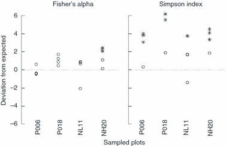

**Figure 2**

Standardized difference of the species diversity in trees minus that in saplings. The standardization was performed by computing this difference in the observed dataset, as well as in 1000 randomized synthetic datasets, and by reporting the observed difference minus the mean of randomized difference divided by the standard deviation of the randomized values. The standardized difference was measured for Fisher’s alpha (left) and for the Simpson index (right), for each of the tree–sapling plots. Stars show significant differences (at the 95% level), while open circles show non-significant differences.

Table 3. Observed changes in species and phylogenetic diversity indices from saplings to trees in each of the 16 sapling–tree plot comparisons. Significant increase are noted by ‘+’, significant decreases by ‘−’, and no significant change by ‘0’. Phylogenetic diversity indices were assessed with four phylogenetic hypotheses: *rbcL* non-ultrametric (tree1), *rbcL* ultrametric (tree2), APG II megatree (tree3), APG II + *rbcL* megatree (tree4)

| Plot | Subplot | Δ Fisher’s alpha | Δ Simpson index | Faith’s PD Tree1 | Faith’s PD Tree2 | Faith’s PD Tree3 | Faith’s PD Tree4 | Rao’s quadratic entropy (Dp) Tree1 | Rao’s quadratic entropy (Dp) Tree2 | Rao’s quadratic entropy (Dp) Tree3 | Rao’s quadratic entropy (Dp) Tree4 |
| --- | --- | --- | --- | --- | --- | --- | --- | --- | --- | --- | --- |
| P006 | A | 0 | + | 0 | 0 | 0 | 0 | 0 | 0 | 0 | 0 |
|  | B | 0 | + | 0 | 0 | 0 | 0 | 0 | 0 | 0 | − |
|  | C | 0 | 0 | 0 | 0 | 0 | 0 | 0 | 0 | 0 | 0 |
|  | D | 0 | + | + | 0 | 0 | 0 | 0 | 0 | 0 | − |
| P018 | A | 0 | + | 0 | 0 | 0 | 0 | 0 | 0 | 0 | 0 |
|  | B | 0 | 0 | + | + | 0 | + | 0 | 0 | 0 | 0 |
|  | C | 0 | + | 0 | 0 | 0 | 0 | 0 | 0 | 0 | 0 |
|  | D | 0 | 0 | 0 | 0 | 0 | 0 | 0 | 0 | 0 | + |
| NL11 | A | 0 | 0 | + | + | + | + | 0 | 0 | 0 | 0 |
|  | B | 0 | + | + | + | + | + | 0 | 0 | 0 | + |
|  | C | 0 | 0 | 0 | 0 | 0 | 0 | 0 | 0 | 0 | 0 |
|  | D | 0 | 0 | 0 | + | + | + | 0 | 0 | 0 | 0 |
| NH20 | A | 0 | 0 | 0 | + | + | + | 0 | 0 | 0 | 0 |
|  | B | 0 | + | 0 | + | + | 0 | 0 | 0 | 0 | + |
|  | C | + | + | 0 | 0 | + | + | 0 | 0 | 0 | 0 |
|  | D | + | + | 0 | + | + | + | 0 | + | 0 | + |

Faith’s PD was significantly higher in the tree than in the sapling assemblages for four to seven of the subplots, depending of the choice of the phylogenetic hypothesis (Fig. 3, Table 3). This pattern was more common at Nouragues than at Paracou.

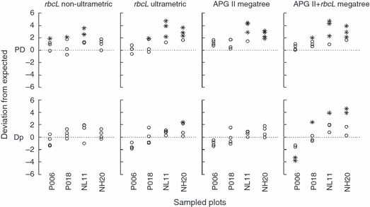

**Figure 3**

Standardized difference of phylogenetic diversity in trees minus that in saplings (see caption of Fig. 2). The four top panels refer to Faith’s phylogenetic diversity (PD). The four bottom panels refer to Rao’s quadratic entropy index (Dp). Each index was estimated with four phylogenetic hypotheses. Stars show significant differences (at the 95% level), while open circles show non-significant differences.

Changes in Rao’s quadratic entropy index (Dp) from saplings to trees were not significantly different from the null hypothesis (Fig. 3, Table 3). However, this finding also depended on the choice of the phylogenetic hypothesis. For instance, using the APG II + *rbcL* phylogeny, four subplots showed significantly higher Dp in trees than in saplings and two subplots showed the reversed pattern.

## Discussion

In this study, we tested the hypothesis that ecological mechanisms continue to shape community structure after seedling establishment. We first tested whether our results could be solely due to dispersal limitation. At the scale of our study, we did not find any effect of dispersal limitation suggesting that a good fraction of the species growing in our saplings plots immigrated from outside. This supports previous findings of pervasive patterns of long-distance dispersal in tropical trees (Webb & Peart 1999; Hardesty, Hubbell & Bermingham 2006; Dick *et al.* 2008). We then used species and phylogenetic diversity indices that capture different aspects of the processes underlying sapling-to-tree transition. Even though single sapling–tree plot comparisons show contrasting results, we discovered that non-random processes operate throughout this size class transition in the tropical plant communities studied. We first discuss the ecological mechanisms detected in our system and then the contribution of molecular data to this investigation.

### Ecological processes shaping the sapling-to-tree transition

For nearly half of our comparisons, we found that evenness was greater in the tree community (higher Simpson index in the tree assemblage), whereas species richness was similar between the sapling and the tree communities (similar Fisher alpha). This scenario is compatible with negative density dependence shaping the sapling-to-tree transition (Table 1). This is consistent with previous demonstrations of negative density dependence during the seed-to-seedling transition (Harms *et al.* 2000) and during the seedling stage (Webb & Peart 1999). It is also in agreement with community scale studies that used demographic data to demonstrate negative density dependence beyond the seedling stage (Wills *et al.* 1997, 2006; Peters 2003; Uriarte *et al.* 2004; Queenborough *et al.* 2007; Comita & Hubbell 2009). Our study sheds little light on the actual mechanisms of density dependence, and it is likely that negative density dependence could be due to the influence of pathogens and herbivores (Gilbert, Hubbell & Foster 1994), which are known to be a strong filter at the seedling stage, but should continue to act on the plants throughout their lifetime (e.g. Novotny *et al.* 2006).

We emphasize that the observed pattern of species diversity could also be explained by storage effect processes. Indeed, storage effects could lead to increasing evenness as different cohorts accumulate in the tree community. In addition, both storage effect and negative density dependence processes are not exclusive. Therefore, it is hard to distinguish between these processes based on our analysis alone. Only long-term studies of sapling communities should provide additional insights on this topic (e.g. Clark & Clark 2001; Wright *et al.* 2005).

In about half of the plots, we found no change in species diversity. This could be interpreted as a result of neutral community dynamics (Table 1). However, in the majority of those plots, Faith’s PD (i.e. phylogenetic richness) was found to be higher in trees than in saplings. This means that tree communities harboured more distant phylogenetic lineages than sapling communities. We also found that these phylogenetically overdispersed lineages should belong to rare taxa, since the abundance-dependent phylogenetic diversity index (Rao’s quadratic entropy, Dp) showed a much less marked signal. Taken together, the patterns encountered in these communities suggest counteracting mechanisms accumulating across size classes. It is impossible to tell apart such counteracting mechanisms in our system. The increase in Faith’s PD in trees was detected in both studied forests, but this pattern was stronger at Nouragues than at Paracou. A possible explanation for this is that Nouragues has undergone fewer disturbances than the Paracou forest, which has favoured the accumulation of rarer species in the tree community through time.

Do our results depend on the assumption of niche conservatism? Such an assumption is often made in phylogenetic community structure studies (Cavender-Bares *et al.* 2009; Vamosi *et al.* 2009), but this assumption needs to be tested, and some recent evidence calls it into question (Swenson & Enquist 2009; see also Losos 2008, for a general overview). If this assumption was falsified, it would be impossible to invoke competition and habitat filtering from patterns of change in diversity (Table 1, Cavender-Bares *et al.* 2004). However, density-dependent processes should still lead to changes in both species and phylogenetic density that are independent of whether niches are conserved.

Overall, this study provides further evidence that negative density dependence continues to operate after the regeneration phase and supports the view that this process is a major mechanism of species coexistence in tropical forests (Givnish 1999; Wright 2002). There is currently much interest in determining whether negative density dependence acts above the species level and in a phylogenetically controlled way (Peters 2003; Uriarte *et al.* 2004; Webb, Gilbert & Donoghue 2006). Comparisons of phylogenetic density between life stages allowed us to conclude that in our forests, density dependence acts among conspecifics, but not across less phylogenetically related groups.

### Relevance of molecular data in tropical forest community ecology

Taxonomic identification in species-rich communities is challenging, particularly at early life stages for which only infertile material is available and leaves are often partially eaten by herbivores. Currently, field identification often requires the collection and germination of identified seeds (Webb & Peart 2000; Kobe & Vriesendorp 2009; Paine & Harms 2009), which can be an exceedingly time-consuming task. DNA-aided taxonomic identification for the saplings allowed us to assign 87% of our individuals to a known taxon. It also improved the assignment to species by 28%. Plant DNA barcoding offers the possibility of greatly advancing sapling identifications with less effort. However, plant DNA barcoding is still in development (CBOL Plant Working Group 2009; Chase & Fay 2009; Fazekas *et al.* 2009), especially in the tropics (Kress & Erickson 2008; Dick & Kress 2009; Gonzalez *et al.* 2009), and its performance in our study remains tightly linked to the availability of an adequate reference database.

An important contribution of molecular data in our study is that we were able to compute phylogeny-based diversity measures directly from our study species. This would have been impossible if we had just sorted the unidentified individuals in morphospecies with no or little indication of familial or generic affiliation. This novel procedure in plant ecology is reminiscent of the approaches commonly conducted not only in microbiology (Green *et al.* 2004; Horner-Devine & Bohannan 2006), but also in mycology (U’Ren *et al.* 2009) and in insect biology (Vogler & Monaghan 2006). The advantage of the present approach is that we can rely on morphological taxonomy to make sure that our species delimitations are consistent and take advantage of high-throughput sequencing technology to generate local phylogenies at an unprecedented resolution and within a consistent framework. Indeed, the integration of phylogenetics into ecological studies has widely been advocated in recent years (Webb *et al.* 2002; Cavender-Bares *et al.* 2004, 2009). For plants, these studies rely mostly on composite trees assembled from the Angiosperm Phylogeny Group (APG II 2003; Webb & Donoghue 2005) and other phylogenies that, however, lack most of the within-family resolution. As a result, inferences based on composite trees may reflect mostly the patterns at the family level and above. By generating a better-resolved phylogeny directly from locally inventoried plants, we could compare the performance of various phylogenetic hypotheses. We found that phylogenetic diversity measures showed the same tendencies, although the better-resolved phylogeny showed higher sensitivity.

We found that most of the variation in our indices of phylogenetic diversity was probably due to the deeper nodes of the phylogeny, as similar results where found with the APG II megatree and the *rbcL* ultrametric tree. This observation is in agreement with a recent study on the importance of phylogenetic resolution, which reported that phylogenetic diversity measures are more sensitive to the information contained in the basal-most clades in a phylogeny (Swenson 2009). However, it is remarkable that when constructing the best possible combination of available data, i.e. the APG II backbone grafted with the family-level *rbcL* subtrees, we did find an increase in the significance of many of our tests. This shows that increasing phylogenetic resolution may increase the sensitivity of our analyses. Similarly, Swenson (2009) found an increase in false negatives with decreasing phylogenetic resolution in his simulations. Even so, our ‘best’ tree reflects primarily patterns at the genus level and above, because *rbcL* does not show great variation among congeneric species. Thus, we expect that better-resolved phylogenetic hypotheses will help increase the quality of inferences in studies of phylogenetic community structure (Vamosi *et al.* 2009).

We further tested if phylogenetic diversity was comparable when recovered from branch lengths representing *rbcL* substitution rates or time distances from calibrated trees. Faith’s PD showed higher sensitivity in the three ultrametric trees than the non-ultrametric *rbcL* phylogeny. However, both choices make critical assumptions, and it is difficult to favour one hypothesis over the other at this stage. Our test on phylogenetic hypothesis performance underlines the need for further development of better-resolved phylogenetic hypotheses and branch length information directly recovered from molecular substitutions rates (Drummond & Rambaut 2007).

## Acknowledgements

We thank all the participants of the BRIDGE project for their help with tree collection and identification, E. Nicolini and B. Riéra for their help in botany, P. Châtelet, P. Charles Dominique, M. Charles Dominique and P. Gaucher for logistical support in French Guiana, and K. Dexter, P.-A. Christin and two anonymous referees for useful comments on previous versions of the manuscript. This work was funded by the ANR-Biodiversité grant BRIDGE and by a CNRS-AMAZONIE grant.

## Citing Literature

[Volume98, Issue1](https://besjournals.onlinelibrary.wiley.com/toc/13652745/2010/98/1)

January 2010

Pages 137-146

beta

- Supporting

  Contrasting0

powered by

[figure not shown]

### Recommended

  [Ecology Letters](https://onlinelibrary.wiley.com/journal/14610248)

[Download PDF](https://besjournals.onlinelibrary.wiley.com/doi/pdf/10.1111/j.1365-2745.2009.01607.x)

back